# Лабораторная по многомерной статистике

### Задание 5

**Считаем тестовые данные и проведём их классификацию по уже построенной модели**:

```r
data2 = data.frame(read_excel("Приложение 3.xlsx"))
data2 = apply(data2, 2, as.numeric) %>% as_data_frame()
data2 = data2[31:80, ]

cluster = predict(rf, data2)$class
data2 = data.frame(cbind(data2, cluster))
data2$cluster = factor(data2$cluster)

data2 %>% tbl_df()
```

| X1 | X2 | X3 | X4 | X5 | X6 | X7 | cluster |
| --- | --- | --- | --- | --- | --- | --- | --- |
| -1080.0 | 3130 | 213.0 | 236 | 33.0 | 11.8 | 807.0 | 4 |
| 403.1 | 2969 | 382.0 | 274 | 29.0 | 5.7 | 728.0 | 3 |
| 139.0 | 3264 | 340.0 | 316 | 28.0 | 6.8 | 711.0 | 4 |
| -444.0 | 3920 | 139.0 | 120 | 9.0 | 13.1 | 464.0 | 4 |
| -833.0 | 5563 | 271.0 | 148 | 15.7 | 8.7 | 426.0 | 3 |
| -380.0 | 5564 | 565.0 | 400 | 48.0 | 14.9 | 1517.0 | 3 |
| -790.0 | 5470 | 432.0 | 509 | 85.0 | 11.8 | 935.0 | 2 |
| -1205.0 | 3698 | 187.5 | 156 | 21.6 | 10.0 | 507.0 | 4 |
| -751.0 | 3448 | 278.0 | 206 | 25.0 | 7.4 | 596.0 | 4 |
| -107.0 | 5868 | 531.0 | 450 | 63.0 | 22.3 | 1608.0 | 2 |

[output cut: 40 more lines]

Построим **диаграммы ядерной плотности** для распределения каждой переменной X1-X7 по отнесенным группам, чтобы убедиться в правильности классификации:

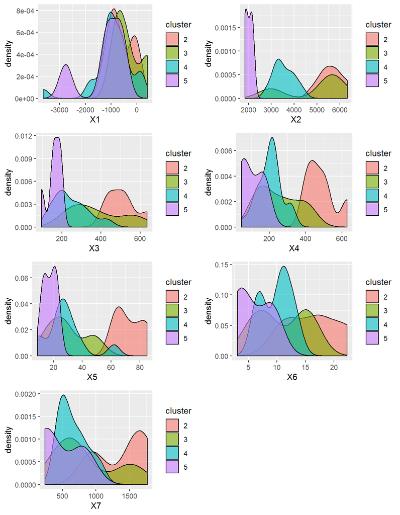

```r
library(ggplot2)
library(ggpubr)

ggarrange(ggplot(data2, aes(x = X1, fill = cluster)) + geom_density(alpha = 0.6),
    ggplot(data2, aes(x = X2, fill = cluster)) + geom_density(alpha = 0.6),
    ggplot(data2, aes(x = X3, fill = cluster)) + geom_density(alpha = 0.6),
    ggplot(data2, aes(x = X4, fill = cluster)) + geom_density(alpha = 0.6),
    ggplot(data2, aes(x = X5, fill = cluster)) + geom_density(alpha = 0.6),
    ggplot(data2, aes(x = X6, fill = cluster)) + geom_density(alpha = 0.6),
    ggplot(data2, aes(x = X7, fill = cluster)) + geom_density(alpha = 0.6),
    ncol = 2, nrow = 4)
```

Другой вариант — **ящики с усами**:

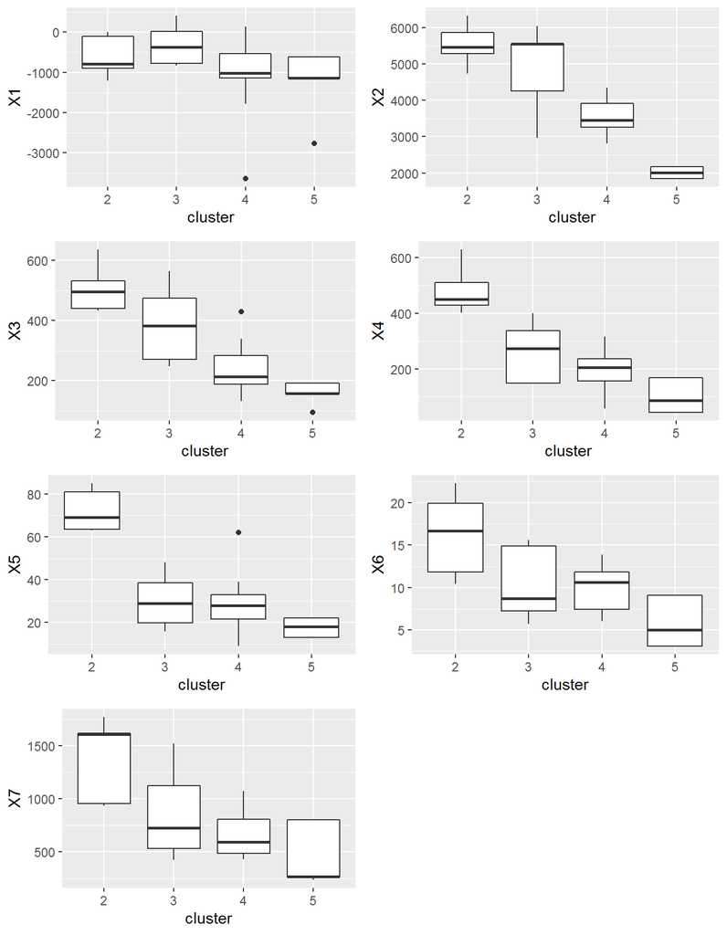

```r
ggarrange(ggplot(data2, aes(x = cluster, y = X1)) + geom_boxplot(), ggplot(data2,
    aes(x = cluster, y = X2)) + geom_boxplot(), ggplot(data2, aes(x = cluster,
    y = X3)) + geom_boxplot(), ggplot(data2, aes(x = cluster, y = X4)) + geom_boxplot(),
    ggplot(data2, aes(x = cluster, y = X5)) + geom_boxplot(), ggplot(data2,
        aes(x = cluster, y = X6)) + geom_boxplot(), ggplot(data2, aes(x = cluster,
        y = X7)) + geom_boxplot(), ncol = 2, nrow = 4)
```

Также **лица Чернова**:

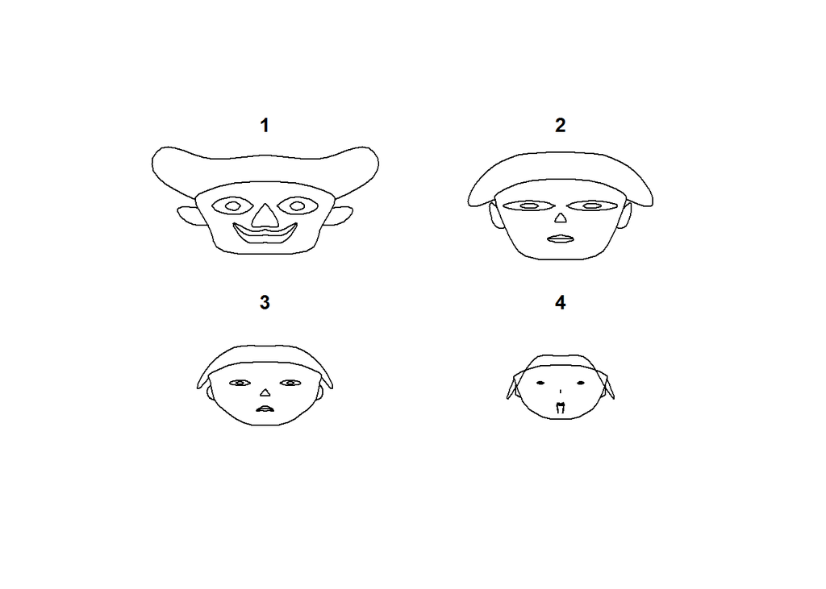

```r
newdata = as_data_frame(data2) %>% group_by(cluster) %>% summarise_all(funs(mean))
faces(newdata[, 2:8])  #рисуем лица
```

**Визуализация через главные компоненты**:

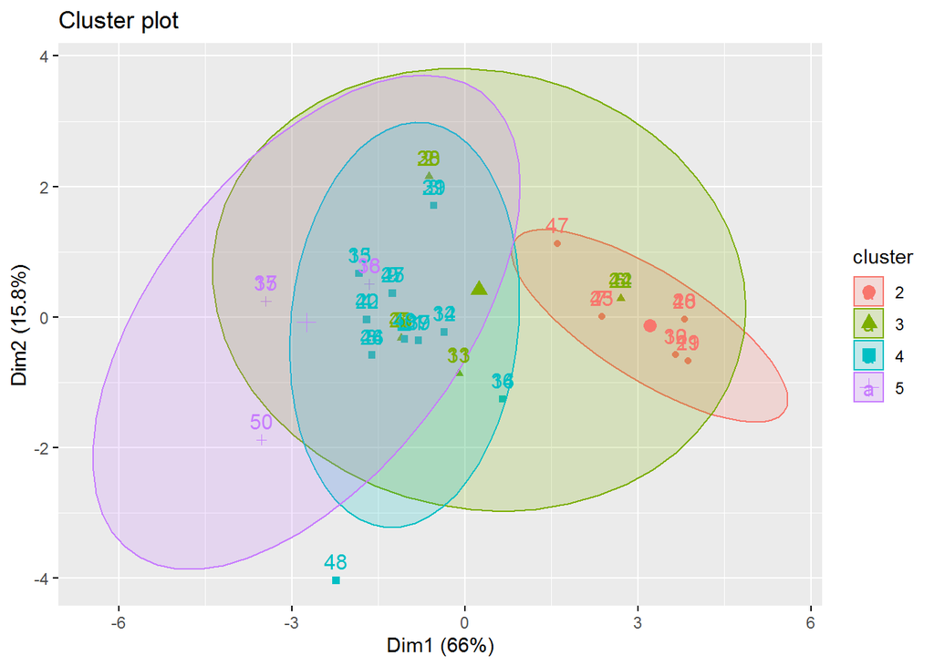

```r
print(fviz_cluster(list(data = data2[, 1:7], cluster = data2[, 8]), ellipse.type = "norm"))
```

В целом качество такое же, как в обучающей выборке.

## Временные ряды

Используются две переменные:

```r
p1 = nchar("Дмитрий")  #число букв в имени
p2 = nchar("Пасько")  #число букв в фамилии
```

### Задание 1

Прочитаем и обработаем **данные**:

```r
library(readxl)
library(dplyr)
tab = data.frame(t(read_xlsx("Рожь18век.xlsx")))
names(tab) = sapply(tab[1, ], as.character)  #поставить правильные названия
tab = tab[-1, ]  #удалить строку с именами
tab = data.frame(Year = sapply(rownames(tab), as.numeric), tab)
tab = sapply(tab, as.numeric)  #факторы перевести в числа
tab %>% tbl_df()
```

| Year | Северный1 | Северный2 | Восточный1 | Восточный2 | ЮгoВосточный1 | ЮгoВосточный2 | Волжский1 | Волжский2 | ЦентральноЧерноземный1 | ЦентральноЧерноземный2 | ЦентральноПечериозельный1 | ЦентральноПечериозельный2 | Украинский1 | Украинский2 | ЗападнаяСибирь1 | ЗападнаяСибирь2 | ЕвропейскаяРоссия1 | ЕвропейскаяРоссия2 |
| --- | --- | --- | --- | --- | --- | --- | --- | --- | --- | --- | --- | --- | --- | --- | --- | --- | --- | --- |
| 1707 | 39 | 31 | 45 | 32 | 20 | 14 | 48 | 35 | 46 | 35 | 37 | 30 | 42 | 25 | 15 | 14 | 37 | 32 |
| 1708 | 44 | 38 | 50 | 39 | 22 | 16 | 49 | 46 | 50 | 40 | 40 | 37 | 46 | 31 | 16 | 16 | 45 | 37 |
| 1709 | 51 | 40 | 41 | 37 | 23 | 17 | 48 | 39 | 43 | 41 | 46 | 38 | 44 | 27 | 15 | 15 | 46 | 37 |
| 1710 | 52 | 42 | 39 | 39 | 24 | 19 | 46 | 42 | 45 | 43 | 52 | 41 | 43 | 29 | 16 | 17 | 48 | 38 |
| 1711 | 57 | 46 | 51 | 41 | NA | NA | 43 | 47 | 48 | 49 | 51 | 46 | 44 | NA | 18 | 18 | 51 | 44 |
| 1712 | 58 | 47 | 52 | 42 | NA | NA | 40 | 38 | 46 | 47 | 50 | 43 | 43 | NA | 22 | 21 | 51 | 40 |
| 1713 | 56 | 48 | 54 | 43 | NA | NA | 43 | 39 | 47 | 48 | 49 | 40 | 42 | NA | 21 | 22 | 48 | 41 |
| 1714 | 1 | 10 | 4 | 1 | NA | NA | 1 | 1 | 1 | 1 | 1 | 1 | 2 | NA | 6 | 5 | 1 | 1 |
| 1715 | 8 | 1 | 2 | 4 | NA | NA | 2 | 3 | 2 | 3 | 2 | 3 | 1 | NA | 4 | 1 | 2 | 2 |
| 1716 | 9 | 8 | 1 | 2 | NA | NA | 6 | 2 | 3 | 2 | 7 | 4 | 5 | NA | NA | NA | 3 | 2 |

[output cut: 52 more lines]

Создадим **фрейм со средними по годам для всей страны и её районов**:

```r
tmptab = tab[, -1]
means = list(rowMeans(tmptab, na.rm = T))
for (i in 1:((ncol(tab) - 1)/2)) {
    means[[i + 1]] = rowMeans(tmptab[, c(i, i + 1)], na.rm = T)
}

means = sapply(means, function(col) sapply(col, function(row) ifelse(is.nan(row),
    NA, row)))  #Заменить все NaN на NA
means = data.frame(tab[, 1], means)
names(means) = c("Year", "Country", "Distrinct1", "Distrinct2", "Distrinct3",
    "Distrinct4", "Distrinct5", "Distrinct6", "Distrinct7", "Distrinct8", "Distrinct9")
means %>% tbl_df()
```

| Year | Country | Distrinct1 | Distrinct2 | Distrinct3 | Distrinct4 | Distrinct5 | Distrinct6 | Distrinct7 | Distrinct8 | Distrinct9 |
| --- | --- | --- | --- | --- | --- | --- | --- | --- | --- | --- |
| 1707 | 32.055556 | 35.0 | 38.0 | 38.5 | 26.0 | 17.0 | 31.0 | 41.5 | 40.5 | 40.5 |
| 1708 | 36.777778 | 41.0 | 44.0 | 44.5 | 30.5 | 19.0 | 32.5 | 47.5 | 48.0 | 45.0 |
| 1709 | 36.000000 | 45.5 | 40.5 | 39.0 | 30.0 | 20.0 | 32.5 | 43.5 | 41.0 | 42.0 |
| 1710 | 37.500000 | 47.0 | 40.5 | 39.0 | 31.5 | 21.5 | 32.5 | 44.0 | 43.5 | 44.0 |
| 1711 | 43.600000 | 51.5 | 48.5 | 46.0 | 41.0 | NA | 43.0 | 45.0 | 47.5 | 48.5 |
| 1712 | 42.666667 | 52.5 | 49.5 | 47.0 | 42.0 | NA | 40.0 | 39.0 | 42.0 | 46.5 |
| 1713 | 42.733333 | 52.0 | 51.0 | 48.5 | 43.0 | NA | 43.0 | 41.0 | 43.0 | 47.5 |
| 1714 | 2.466667 | 5.5 | 7.0 | 2.5 | 1.0 | NA | 1.0 | 1.0 | 1.0 | 1.0 |
| 1715 | 2.666667 | 4.5 | 1.5 | 3.0 | 4.0 | NA | 2.0 | 2.5 | 2.5 | 2.5 |
| 1716 | 4.153846 | 8.5 | 4.5 | 1.5 | 2.0 | NA | 6.0 | 4.0 | 2.5 | 2.5 |

[output cut: 52 more lines]

Визуализация полученных значений показывает, что *в целом цена ведёт себя одинаково по всем регионам*:

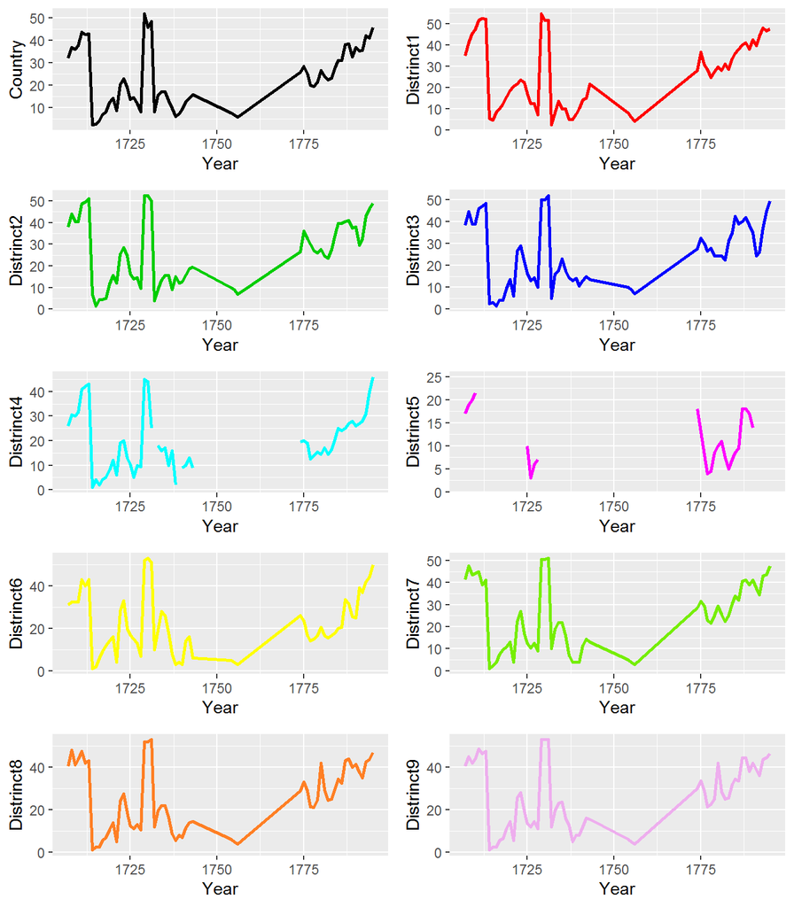

```r
library(ggplot2)
g1 = ggplot(means, aes(x = Year)) + geom_line(aes(y = Country), size = 1)
g2 = ggplot(means, aes(x = Year)) + geom_line(aes(y = Distrinct1), size = 1,
    col = 2)
g3 = ggplot(means, aes(x = Year)) + geom_line(aes(y = Distrinct2), size = 1,
    col = 3)
g4 = ggplot(means, aes(x = Year)) + geom_line(aes(y = Distrinct3), size = 1,
    col = 4)
g5 = ggplot(means, aes(x = Year)) + geom_line(aes(y = Distrinct4), size = 1,
    col = 5)
g6 = ggplot(means, aes(x = Year)) + geom_line(aes(y = Distrinct5), size = 1,
    col = 6)
g7 = ggplot(means, aes(x = Year)) + geom_line(aes(y = Distrinct6), size = 1,
    col = 7)
g8 = ggplot(means, aes(x = Year)) + geom_line(aes(y = Distrinct7), size = 1,
    col = "chartreuse2")
g9 = ggplot(means, aes(x = Year)) + geom_line(aes(y = Distrinct8), size = 1,
    col = "chocolate1")
g10 = ggplot(means, aes(x = Year)) + geom_line(aes(y = Distrinct9), size = 1,
    col = "plum2")
library(ggpubr)
ggarrange(g1, g2, g3, g4, g5, g6, g7, g8, g9, g10, nrow = 5, ncol = 2)
```

Зададим **новый временной ряд**:

```r
price1 = c(40 + p1, 43 + p1, 40, 80, 74, 40 + p2, 55 + p2, 42 + p2, 42, 50,
    40 + p2, 43, 43, 35 + p1, 40 + p1, 30, 36 + p1, 50, 30 + p1, 29, 45 + p1,
    40, 42, 40, 36, 50, 30 + p1, 24 + p2, 25 + p2, 40, 32 + p1, 30, 20, 30,
    25, 32 + p2)
cat("Длина вектора:", length(price1), "\n")
```

```
## Длина вектора: 36
```

```r
summary(price1)  #минимальные характеристики
```

```
##    Min. 1st Qu.  Median    Mean 3rd Qu.    Max.
##   20.00   36.75   42.00   42.44   47.25   80.00
```

*Тест Стьюдента* для среднего значения (42.4444444) показывает **значимое отличие среднего ряда от нуля (p-value очень близкое к нулю)**:

```r
(ts = t.test(price1, conf.level = 0.95))  #тест Стьюдента для среднего
```

```
##
##  One Sample t-test
##
## data:  price1
## t = 21.17, df = 35, p-value < 2.2e-16
## alternative hypothesis: true mean is not equal to 0
## 95 percent confidence interval:
##  38.37422 46.51467
## sample estimates:
## mean of x
##  42.44444
```

```r
cat("Доверительный интервал: ", ts$conf.int, "\n")
```

```
## Доверительный интервал:  38.37422 46.51467
```

```r
cat("Стандартная ошибка среднего: ", ts$stderr, "\n")
```

```
## Стандартная ошибка среднего:  2.004932
```

а **низкий коэффициент вариации говорит об однородности выборки**

```r
vart = sd(price1)/mean(price1) * 100
cat("Коэффициент вариации равен", vart, "%\n")
```

```
## Коэффициент вариации равен 28.34197 %
```

```r
# так как коэффициент вариации < 30%, выборка достаточно однородная
```

**Замечание:** в проведённом тесте Стьюдента число степеней свободы было на 1 (а не на 2) меньше числа наблюдений, так как при тесте использовалась одна выборка. Можно считать, что исходная выборка сравнивается с выборкой из единственного элемента 0, поэтому число степеней свободы всего на 1 меньше числа наблюдений. Так же определяется число степеней свободы, например, [здесь](https://statpsy.ru/t-student/primer-t-test-single/).

### Задание 3

Создадим и визуализируем **временной ряд**:

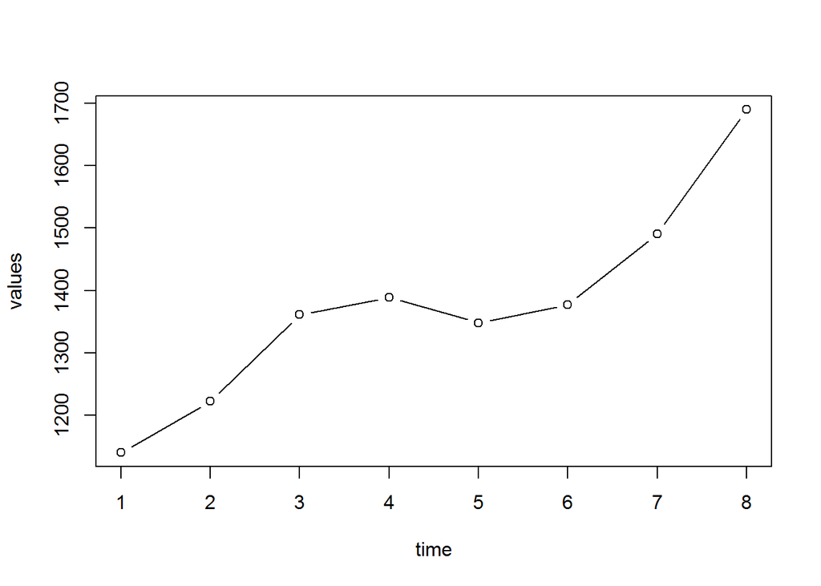

```r
library(ggplot2)

yt = c(1133 + p1, 1222, 1354 + p1, 1389, 1342 + p2, 1377, 1491, 1684 + p2)
data = data.frame(time = 1:length(yt), values = yt)
plot(data, type = "b")
```

В целом, здесь наблюдается линейная составляющая. Построим линейную модель и **регрессионную прямую**:

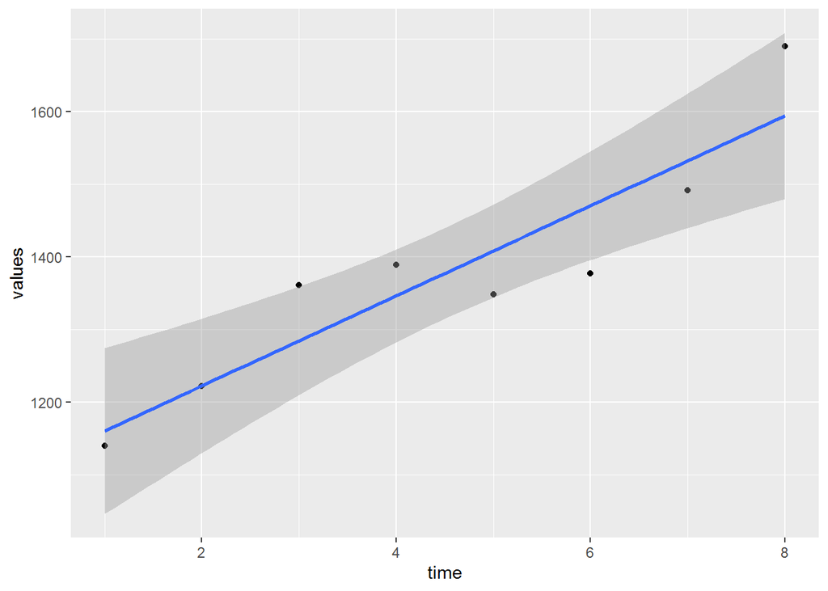

```r
fit = lm(values ~ time, data)  #создание модели
ggplot(data, aes(x = time, y = values)) + geom_point() + geom_smooth(method = lm)
```

Посмотрим **информацию о модели**:

```r
summary(fit)  #информация о модели
```

```
##
## Call:
## lm(formula = values ~ time, data = data)
##
## Residuals:
##    Min     1Q Median     3Q    Max
## -93.14 -45.86 -10.46  51.20  96.00
##
## Coefficients:
##             Estimate Std. Error t value Pr(>|t|)
## (Intercept)  1098.57      56.30  19.513 1.17e-06 ***
## time           61.93      11.15   5.555  0.00144 **
## ---
## Signif. codes:  0 '***' 0.001 '**' 0.01 '*' 0.05 '.' 0.1 ' ' 1
##
## Residual standard error: 72.25 on 6 degrees of freedom
## Multiple R-squared:  0.8372, Adjusted R-squared:  0.8101
## F-statistic: 30.85 on 1 and 6 DF,  p-value: 0.00144
```

```r
confint(fit, level = 0.95)  #доверительные интервалы
```

```
##                 2.5 %     97.5 %
## (Intercept) 960.81185 1236.33101
## time         34.64811   89.20903
```

Самое важное здесь — модель описывает более 80% дисперсий (**Adjusted R-squared**), каждый её коэффициент (**Pr(>|t|)**) и она сама (**p-value** в самом низу, в строке с **F-statistic**) статистически значимы (поскольку p-value меньше 0.05). **Estimate** — это коэффициенты модели, значит сама регресионная прямая имеет вид
$$y=1098.57 + 61.93 t$$

Коэффициент при $t$ показывает, на сколько в среднем увеличится $y$ при изменении $t$ на единицу. Дисперсионный анализ можно выполнить и отдельно с тем же результатом:

```r
anova(fit)
```

|  | Df | Sum Sq | Mean Sq | F value | Pr(>F) |
| --- | --- | --- | --- | --- | --- |
| time | 1 | 161076.21 | 161076.214 | 30.85428 | 0.00143987 |
| Residuals | 6 | 31323.29 | 5220.548 | NA | NA |

Теперь выполним [прогноз для среднего и индивидульного значений](http://www.sthda.com/english/articles/40-regression-analysis/166-predict-in-r-model-predictions-and-confidence-intervals/) при $t=9$:

```r
# прогноз среднего
predict(fit, data.frame(time = c(9)), se.fit = TRUE, interval = "confidence",
    level = 0.95)$fit
```

```
##        fit      lwr      upr
## 1 1655.929 1518.169 1793.688
```

```r
# прогноз индивидуального
predict(fit, data.frame(time = c(9)), se.fit = TRUE, interval = "prediction",
    level = 0.95)$fit
```

```
##        fit      lwr     upr
## 1 1655.929 1431.797 1880.06
```

Здесь первое число — само предсказанное значение, последующие — границы доверительного интервала.Итак, само предсказанное значение равно 1655.929, доверительный интервал для среднего: [1518.169,1793.688], для индивидуального: [1431.797,1880.06].

### Задание 4

Считаем **набор данных** и проведём некоторую обработку:

```r
library(readxl)
data = data.frame(read_xlsx("РожьВсеГода.xlsx"))
data[, -1] = apply(data[, -1], 2, as.numeric)  #перевести в числа все строки
y = t(data[, -1])  #транспонирование для удобства

# получить массив лет
ns = rownames(y)
x = sapply(ns, function(s) as.numeric(substr(s, 2, nchar(s))))

library(mice)  #обработать пустые значения
imp = mice(y, seed = 11)
y = complete(imp, action = 1)

df = data.frame(x = x, y = y[, 2])  #объединить данные в фрейм

# print(df[sort(sample(1:nrow(df),13)),2,drop=FALSE]) #вывести 13 случайных
# строк
```

Получаем:

```r
df %>% tbl_df()
```

| x | y |
| --- | --- |
| 1707 | 26 |
| 1708 | 32 |
| 1709 | 23 |
| 1710 | 20 |
| 1711 | 35 |
| 1712 | 39 |
| 1713 | 41 |
| 1714 | 38 |
| 1715 | 34 |
| 1716 | 31 |

[output cut: 128 more lines]

При этом пропущенные значения были обработаны по алгоритму [MICE](http://citeseerx.ist.psu.edu/viewdoc/download?doi=10.1.1.169.5745&rep=rep1&type=pdf), **для дальнейшего исследования был взят второй район**. Визуализировав данные по нему

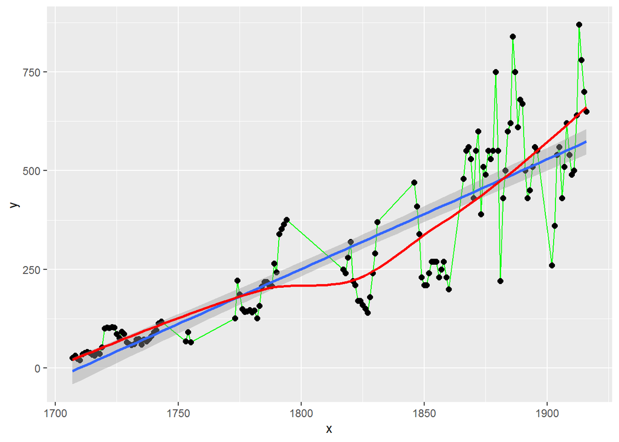

```r
library(ggplot2)
ggplot(df, aes(x = x, y = y)) + geom_line(col = "green") + geom_point(size = 2) +
    geom_smooth(method = lm) + geom_smooth(se = F, col = "red")
```

приходим к выводу, что в целом поведение цен можно описать линейной моделью, однако для обычной линейной модели здесь явно не будет выполняться требование гомоскедастичности. Попробуем разные **преобразования данных** (качество модели определяется величиной Adjusted R-squared):

```r
summary(lm(y ~ x, df))
```

```
##
## Call:
## lm(formula = y ~ x, data = df)
##
## Residuals:
##     Min      1Q  Median      3Q     Max
## -274.50  -52.12    7.23   45.45  349.99
##
## Coefficients:
##               Estimate Std. Error t value Pr(>|t|)
## (Intercept) -4754.7565   241.9835  -19.65   <2e-16 ***
## x               2.7809     0.1333   20.87   <2e-16 ***
## ---
## Signif. codes:  0 '***' 0.001 '**' 0.01 '*' 0.05 '.' 0.1 ' ' 1
##
## Residual standard error: 105.9 on 136 degrees of freedom
## Multiple R-squared:  0.762,  Adjusted R-squared:  0.7603
## F-statistic: 435.5 on 1 and 136 DF,  p-value: < 2.2e-16
```

```r
summary(lm(sqrt(y) ~ x, df))
```

```
##
## Call:
## lm(formula = sqrt(y) ~ x, data = df)
##
## Residuals:
##    Min     1Q Median     3Q    Max
## -7.370 -1.454 -0.163  1.628  6.901
##
## Coefficients:
##               Estimate Std. Error t value Pr(>|t|)
## (Intercept) -1.444e+02  6.017e+00  -24.00   <2e-16 ***
## x            8.829e-02  3.314e-03   26.65   <2e-16 ***
## ---
## Signif. codes:  0 '***' 0.001 '**' 0.01 '*' 0.05 '.' 0.1 ' ' 1
##
## Residual standard error: 2.633 on 136 degrees of freedom
## Multiple R-squared:  0.8392, Adjusted R-squared:  0.8381
## F-statistic:   710 on 1 and 136 DF,  p-value: < 2.2e-16
```

```r
summary(lm(log(y) ~ x, df))
```

```
##
## Call:
## lm(formula = log(y) ~ x, data = df)
##
## Residuals:
##      Min       1Q   Median       3Q      Max
## -1.00146 -0.26602 -0.00776  0.26103  0.87028
##
## Coefficients:
##               Estimate Std. Error t value Pr(>|t|)
## (Intercept) -1.762e+01  8.398e-01  -20.99   <2e-16 ***
## x            1.264e-02  4.625e-04   27.34   <2e-16 ***
## ---
## Signif. codes:  0 '***' 0.001 '**' 0.01 '*' 0.05 '.' 0.1 ' ' 1
##
## Residual standard error: 0.3675 on 136 degrees of freedom
## Multiple R-squared:  0.8461, Adjusted R-squared:  0.8449
## F-statistic: 747.6 on 1 and 136 DF,  p-value: < 2.2e-16
```

```r
summary(lm(log(y) ~ log(x), df))
```

```
##
## Call:
## lm(formula = log(y) ~ log(x), data = df)
##
## Residuals:
##      Min       1Q   Median       3Q      Max
## -0.97970 -0.26965 -0.00275  0.25610  0.85541
##
## Coefficients:
##              Estimate Std. Error t value Pr(>|t|)
## (Intercept) -166.5906     6.2023  -26.86   <2e-16 ***
## log(x)        22.9125     0.8266   27.72   <2e-16 ***
## ---
## Signif. codes:  0 '***' 0.001 '**' 0.01 '*' 0.05 '.' 0.1 ' ' 1
##
## Residual standard error: 0.3633 on 136 degrees of freedom
## Multiple R-squared:  0.8496, Adjusted R-squared:  0.8485
## F-statistic: 768.3 on 1 and 136 DF,  p-value: < 2.2e-16
```

Видно, что *модель с логарифмами описывает почти 85% дисперсий*, поэтому в дальнейшем будем использовать её. Эта модель имеет вид:
$$\log y = -166.5906+22.9125 \log x$$
а иначе:
$$y=e^{-166.5906}x^{22.9125}$$

Построим тот же график:

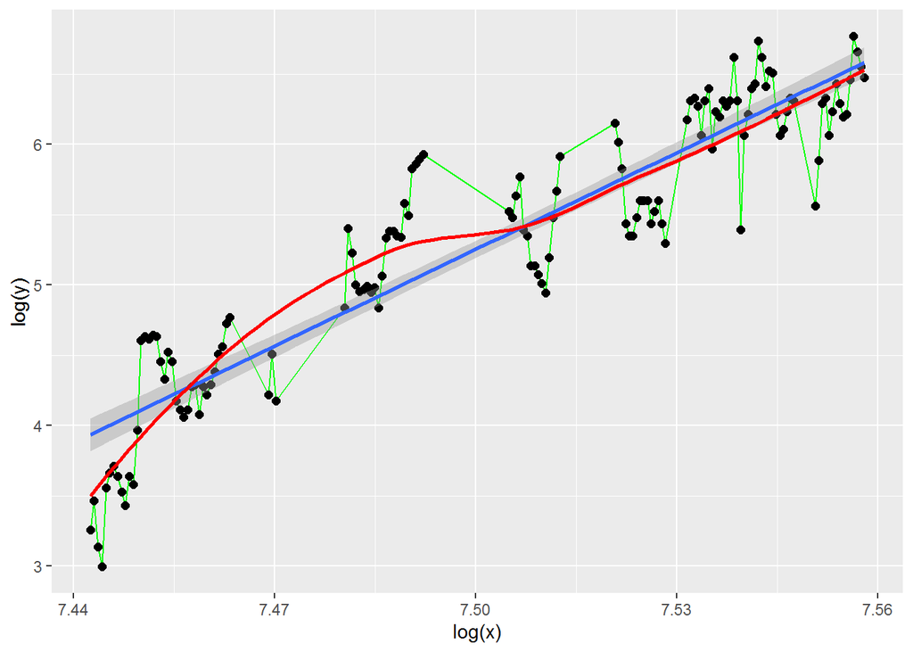

```r
ggplot(df, aes(x = log(x), y = log(y))) + geom_line(col = "green") + geom_point(size = 2) +
    geom_smooth(method = lm) + geom_smooth(se = F, col = "red")
```

**Для остатков полученной модели проведём сглаживание методом k-средних**:

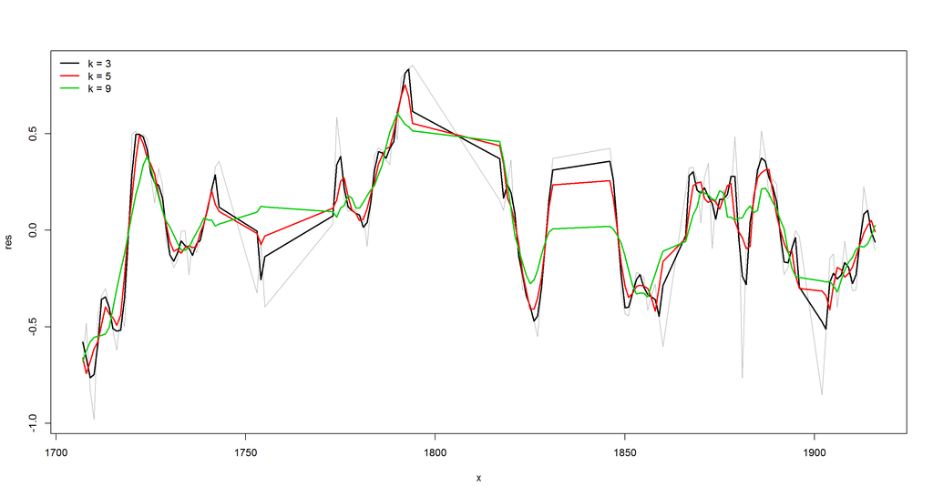

```r
mt = lm(log(y) ~ log(x), df)
res = mt$residuals
# скользящее среднее
library(caTools)
k = c(3, 5, 9)
plot(x, res, type = "l", col = "grey")
for (i in 1:length(k)) {
    lines(x, runmean(res, k[i]), col = i, lwd = 2)
}

legend("topleft", c(paste("k =", k)), col = 1:length(k), bty = "n", lwd = 2)
```

Построим график этой модели в исходной системе координат:

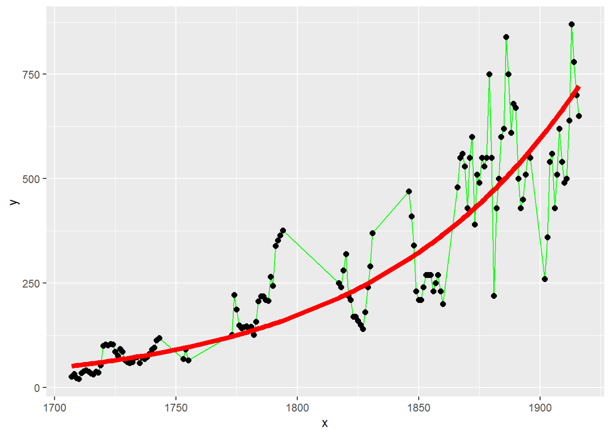

```r
ggplot(df, aes(x = x, y = y)) + geom_line(col = "green") + geom_point(size = 2) +
    geom_line(aes(x = x, y = exp(-166.5906) * x^22.9125), col = "red", size = 2)
```

И последнее: **визуализируем корреляции между всеми исходными районами за последние 60 лет наблюдений по отрезкам в 20 лет**:

```
## Times: 1846 1847 1848 1849 1850 1851 1852 1853 1854 1855 1856 1857 1858 1859 1860 1866 1867 1868 1869 1870
## Матрица корреляций:
##           V1        V2        V3        V4        V5        V6
## V1 1.0000000 0.8291448 0.5366430 0.6129233 0.8161189 0.1555005
## V2 0.8291448 1.0000000 0.7717488 0.7558893 0.7731484 0.5312709
## V3 0.5366430 0.7717488 1.0000000 0.5726800 0.6073105 0.7487677
## V4 0.6129233 0.7558893 0.5726800 1.0000000 0.6249769 0.2797815
## V5 0.8161189 0.7731484 0.6073105 0.6249769 1.0000000 0.1852402
## V6 0.1555005 0.5312709 0.7487677 0.2797815 0.1852402 1.0000000
## Статистика по треугольнику корреляционной матрицы
##    Min. 1st Qu.  Median    Mean 3rd Qu.    Max.
##  0.1555  0.5340  0.6129  0.5867  0.7638  0.8291
```

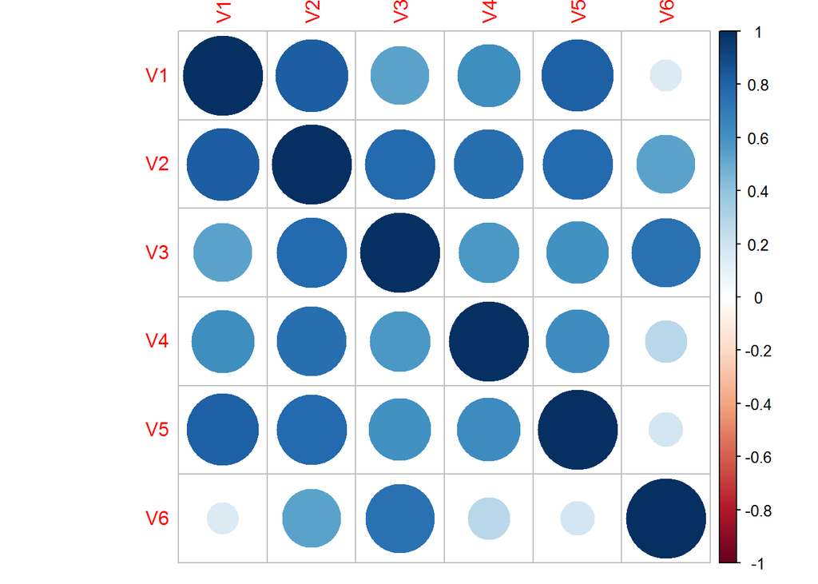

```
## Times: 1871 1872 1873 1874 1875 1876 1877 1878 1879 1880 1881 1882 1883 1884 1885 1886 1887 1888 1889 1890
## Матрица корреляций:
##            V1         V2        V3         V4        V5         V6
## V1  1.0000000  0.7649144 0.3027825  0.8765815 0.4005356 -0.5869152
## V2  0.7649144  1.0000000 0.2207233  0.5826532 0.1561994 -0.6556954
## V3  0.3027825  0.2207233 1.0000000  0.5261564 0.8357040  0.2055036
## V4  0.8765815  0.5826532 0.5261564  1.0000000 0.6427869 -0.3945789
## V5  0.4005356  0.1561994 0.8357040  0.6427869 1.0000000  0.2367902
## V6 -0.5869152 -0.6556954 0.2055036 -0.3945789 0.2367902  1.0000000
## Статистика по треугольнику корреляционной матрицы
##    Min. 1st Qu.  Median    Mean 3rd Qu.    Max.
##  0.1562  0.2698  0.5262  0.4926  0.6492  0.8766
```

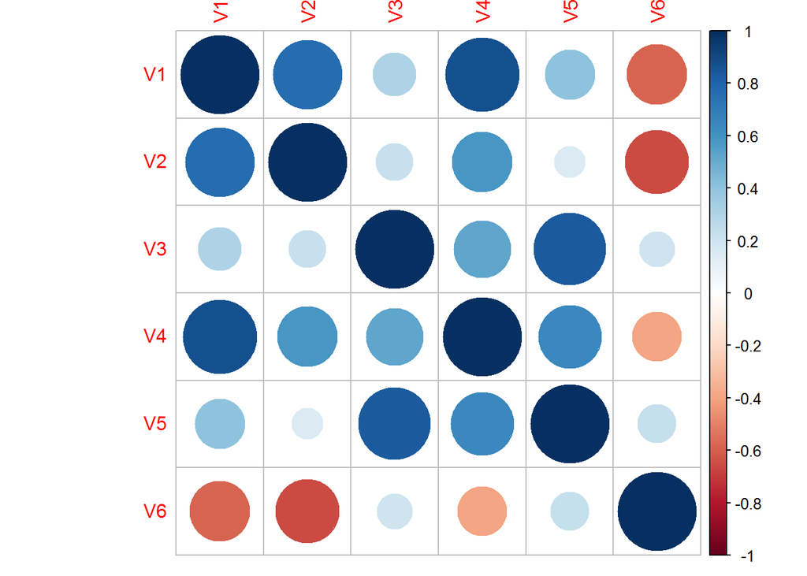

```
## Times: 1891 1892 1893 1894 1895 1896 1902 1903 1904 1905 1906 1907 1908 1909 1910 1911 1912 1913 1914 1915
## Матрица корреляций:
##            V1         V2         V3         V4         V5         V6
## V1  1.0000000  0.8424524  0.8816869  0.8683768  0.9197496 -0.1501039
## V2  0.8424524  1.0000000  0.8579754  0.9580594  0.8652964 -0.2309437
## V3  0.8816869  0.8579754  1.0000000  0.8514249  0.8895560 -0.4079528
## V4  0.8683768  0.9580594  0.8514249  1.0000000  0.9179652 -0.2816789
## V5  0.9197496  0.8652964  0.8895560  0.9179652  1.0000000 -0.2186937
## V6 -0.1501039 -0.2309437 -0.4079528 -0.2816789 -0.2186937  1.0000000
## Статистика по треугольнику корреляционной матрицы
##    Min. 1st Qu.  Median    Mean 3rd Qu.    Max.
##  0.1501  0.3448  0.8580  0.6761  0.8856  0.9581
```

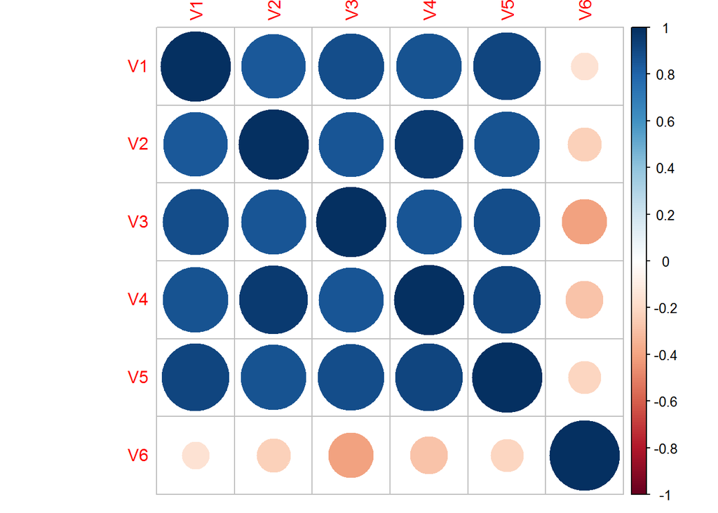

```r
nn = 20

for (i in seq(length(x) - 60, length(x) - nn, nn)) {
    tmp = i:(i + nn - 1)
    cat("Times:", x[tmp], "\n")
    data = y[tmp, ]
    cormatrix = cor(data)
    cat("Матрица корреляций:\n")
    print(cormatrix)
    lower = abs(cormatrix[lower.tri(cormatrix)])
    cat("Статистика по треугольнику корреляционной матрицы \n")
    print(summary(lower[lower != 0]))
    corrplot(cormatrix)
}
```

Наглядно видно, что ближе к концу наблюдений корреляция между переменными возрастает. Проблемы с шестой переменной связаны с тем, что для неё было очень много пропущенных значений.